# R Notebook

# TP2 de de séries temporelles linéaires

```r
rm(list = ls())
library(zoo) #format de serie temporelle pratique et facile d'utilisation (mais plus volumineux)
library("ggplot2")
library("tseries")
```

### Question 1 - importation des données

```r
source = read.csv(file = "./Donnees/Donnees_TP2.csv", sep =";")
```

### Question 2 - première représentation graphique

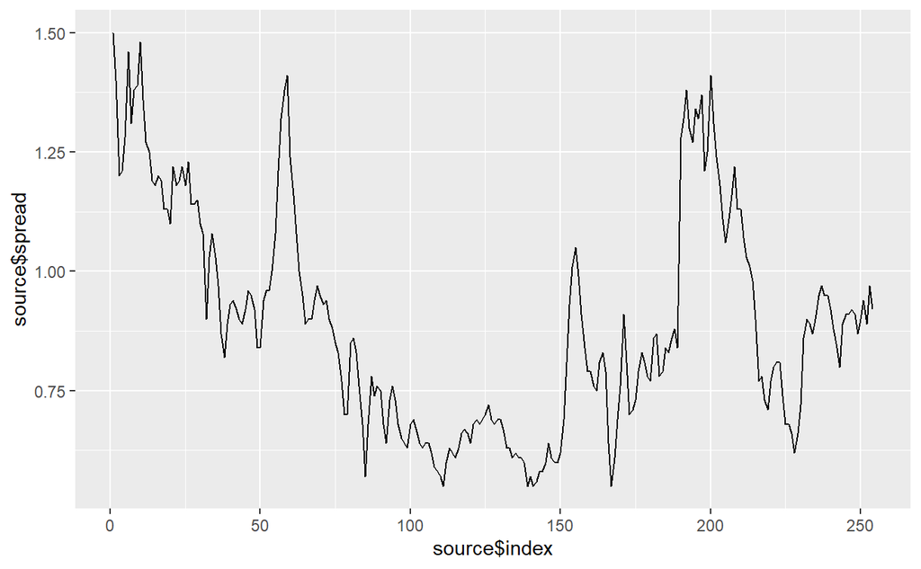

```r
index = c(1:254)
source = as.data.frame(cbind(source,index)) # La correction fait une chose équivalente de manière plus élégante.


p_spread = ggplot(data = source) + geom_line(aes(x = source$index,y=source$spread))
p_spread
```

```r
NA
NA
```

Cela évoque une marche aléatoire.

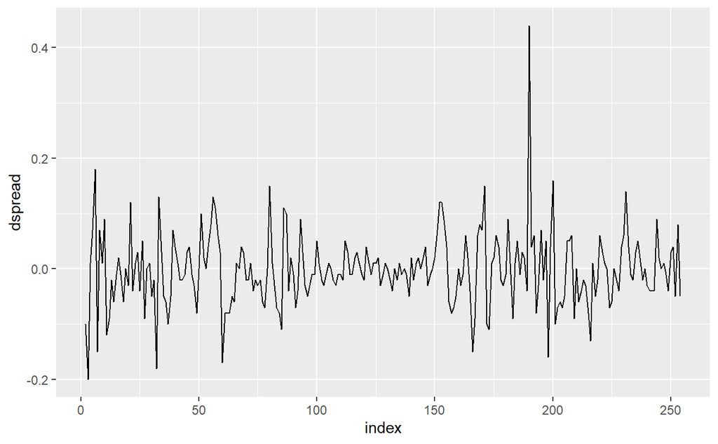

```r
dspread = diff(source$spread)
index = 2:254

df_diff = cbind.data.frame(index,dspread)
ggplot(data=df_diff)+geom_line(aes(x=index,y=dspread))
```

La série brute semble être persistante et avoir une tendance linéaire, voire non déterministe : elle évoque une marché aléatoire.

Cependant, sa transformation *first difference* a évoque une série stationnaire. Cela ressemble à un bruit blanc, aussi peut-être un ARMA ou autre chose..

Ainsi, la série du spread est probablement $I(1)$.

### Question 3

```r
summary(lm(source$spread ~ source$index))
```

```
Call:
lm(formula = source$spread ~ source$index)

Residuals:
     Min       1Q   Median       3Q      Max
-0.35663 -0.19280 -0.03509  0.14884  0.57802

Coefficients:
               Estimate Std. Error t value Pr(>|t|)
(Intercept)   0.9965943  0.0284285  35.056  < 2e-16 ***
source$index -0.0008231  0.0001933  -4.258 2.91e-05 ***
---
Signif. codes:  0 ‘***’ 0.001 ‘**’ 0.01 ‘*’ 0.05 ‘.’ 0.1 ‘ ’ 1

Residual standard error: 0.2259 on 252 degrees of freedom
Multiple R-squared:  0.06713,   Adjusted R-squared:  0.06342
F-statistic: 18.13 on 1 and 252 DF,  p-value: 2.91e-05
```

Le coefficient de index est bien négatif et peut-être statistiquement significatif *(on ne peut pas vraiment le confirmer, car le test n’est pas valide en présence de résidus autocorrélés)*. Donc on va être dans le cas des tests de racine unitaire avec constante et tendance non nulles.

D’où le test de Dicket-Fuller qui va être utilisé (et non Philipps-Perron comme dans le TP1).

```r
#library("fUnitRoots")

Qtests <- function(series, k, fitdf=0) {
  pvals <- apply(matrix(1:k), 1, FUN=function(l) {
    pval <- if (l<=fitdf) NA else Box.test(series, lag=l, type="Ljung-Box", fitdf=fitdf)$p.value
    return(c("lag"=l,"pval"=pval))
  })
  return(t(pvals))
}

adf <- fUnitRoots::adfTest(source$spread, lag=0, type="ct") #
# adf

Qtests(adf@test$lm$residuals, 24, fitdf = length(adf@test$lm$coefficients))
```

```
      lag         pval
 [1,]   1           NA
 [2,]   2           NA
 [3,]   3           NA
 [4,]   4 0.0001653553
 [5,]   5 0.0006228068
 [6,]   6 0.0020253166
 [7,]   7 0.0048178976
 [8,]   8 0.0053287554
 [9,]   9 0.0107522173
[10,]  10 0.0144275844
[11,]  11 0.0251292647
[12,]  12 0.0402752956
[13,]  13 0.0546570005
[14,]  14 0.0763152444
[15,]  15 0.1084170353
[16,]  16 0.1459326222
[17,]  17 0.1919718170
[18,]  18 0.2314483894
[19,]  19 0.2493648556
[20,]  20 0.2971825207
[21,]  21 0.3050056430
[22,]  22 0.3387227731
[23,]  23 0.3947387545
[24,]  24 0.4451272327
```

Déterminons le nombre de retard de $\Delta X_t$ nécessaires pour que les résidus ne soient plus autocorrélés.

```r
library(fUnitRoots)
series <- source$spread; kmax <- 24; adftype="ct"

adfTest_valid <- function(series, kmax, adftype){
  k <- 0
  noautocorr <- 0
  while (noautocorr==0){
    cat(paste0("ADF with ",k," lags: residuals OK? "))
    adf <- adfTest(series, lags=k, type=adftype)
    pvals <- Qtests(adf@test$lm$residuals, 24, fitdf = length(adf@test$lm$coefficients))[,2]
    if (sum(pvals<0.05,na.rm=T)==0) {
      noautocorr <- 1; cat("OK \n")
    } else cat("No \n")
    k <- k+1
  }
  return(adf)
}
adf <- adfTest_valid(series,24,adftype="ct")
```

```
ADF with 0 lags: residuals OK? No
ADF with 1 lags: residuals OK? No
ADF with 2 lags: residuals OK? No
ADF with 3 lags: residuals OK? No
ADF with 4 lags: residuals OK? No
ADF with 5 lags: residuals OK? No
ADF with 6 lags: residuals OK? No
ADF with 7 lags: residuals OK? No
ADF with 8 lags: residuals OK? No
ADF with 9 lags: residuals OK? No
ADF with 10 lags: residuals OK? No
ADF with 11 lags: residuals OK? No
ADF with 12 lags: residuals OK? No
ADF with 13 lags: residuals OK? OK
```

```r
#
Qtests(adf@test$lm$residuals, 24, fitdf = length(adf@test$lm$coefficients))
```

```
      lag      pval
 [1,]   1        NA
 [2,]   2        NA
 [3,]   3        NA
 [4,]   4        NA
 [5,]   5        NA
 [6,]   6        NA
 [7,]   7        NA
 [8,]   8        NA
 [9,]   9        NA
[10,]  10        NA
[11,]  11        NA
[12,]  12        NA
[13,]  13        NA
[14,]  14        NA
[15,]  15        NA
[16,]  16        NA
[17,]  17 0.1165945
[18,]  18 0.1895988
[19,]  19 0.2790347
[20,]  20 0.2747749
[21,]  21 0.3983341
[22,]  22 0.5052502
[23,]  23 0.6198172
[24,]  24 0.6334153
```

```r
#
adf
```

```
Title:
 Augmented Dickey-Fuller Test

Test Results:
  PARAMETER:
    Lag Order: 13
  STATISTIC:
    Dickey-Fuller: -2.5543
  P VALUE:
    0.3424

Description:
 Sat Apr 22 11:42:38 2023 by user: louis
```

```r
#
summary(lm(dspread ~ source$dates[-1]))
```

[output not shown]

[output cut: 208 more lines]

[output not shown]

```r
#
adf <- adfTest_valid(dspread,24,"nc")
```

```
ADF with 0 lags: residuals OK?
```

```
OK
```

```r
#
Qtests(adf@test$lm$residuals, 24, fitdf = length(adf@test$lm$coefficients))
```

```
      lag      pval
 [1,]   1        NA
 [2,]   2 0.6727631
 [3,]   3 0.1080988
 [4,]   4 0.0918078
 [5,]   5 0.1362508
 [6,]   6 0.2144268
 [7,]   7 0.2836747
 [8,]   8 0.2297896
 [9,]   9 0.3062914
[10,]  10 0.3374371
[11,]  11 0.4258476
[12,]  12 0.4880805
[13,]  13 0.5257624
[14,]  14 0.5751874
[15,]  15 0.6505810
[16,]  16 0.7172656
[17,]  17 0.7716511
[18,]  18 0.7983010
[19,]  19 0.8085879
[20,]  20 0.8509897
[21,]  21 0.8582274
[22,]  22 0.8813602
[23,]  23 0.9037221
[24,]  24 0.9219713
```

```r
adf
```

```
Title:
 Augmented Dickey-Fuller Test

Test Results:
  PARAMETER:
    Lag Order: 0
  STATISTIC:
    Dickey-Fuller: -13.5536
  P VALUE:
    0.01

Description:
 Sat Apr 22 11:42:39 2023 by user: louis
```

Les tests réalisés indiquent qu’on a besoin de 13 retards pour supprimer l’autocorrélation des résidus.

On effectue donc le test ADF avec 13 retards.

```r
fUnitRoots::adfTest(source$spread,lag = 13, type="ct")
```

```
Title:
 Augmented Dickey-Fuller Test

Test Results:
  PARAMETER:
    Lag Order: 13
  STATISTIC:
    Dickey-Fuller: -2.5543
  P VALUE:
    0.3424

Description:
 Mon Apr 17 11:34:57 2023 by user: louis
```

L’hypothèse de racine unitaire n’est pas rejetée au seul de $5\%$ pour la série en niveau, la série est donc au moins $I(1)$.

On travaille donc maintenant sur la série différenciée. Pour vérifier l’absence de constante et de tendance déterministe, on fait une régression et on regarde la significativité statistique des coefficients :

```r
reg = lm(df_diff$dspread ~ df_diff$index)

summary(reg)
```

```
Call:
lm(formula = df_diff$dspread ~ df_diff$index)

Residuals:
     Min       1Q   Median       3Q      Max
-0.19022 -0.03555 -0.00358  0.03433  0.43858

Coefficients:
                Estimate Std. Error t value Pr(>|t|)
(Intercept)   -9.962e-03  8.432e-03  -1.181    0.239
df_diff$index  5.992e-05  5.721e-05   1.047    0.296

Residual standard error: 0.06647 on 251 degrees of freedom
Multiple R-squared:  0.00435,   Adjusted R-squared:  0.0003837
F-statistic: 1.097 on 1 and 251 DF,  p-value: 0.296
```

On ne rejette pas au seuil de 10% que la constante et la tendance soient non nulles.

```r
adf_dspread = fUnitRoots::adfTest(df_diff$dspread, lag=0, type="nc")
# Avant d'interpréter la p-valeur, il faut vérifier l'absence d'autocorrélations des résidus

Qtests(adf_dspread@test$lm$residuals, 24, fitdf = length(adf_dspread@test$lm$coefficients))
```

```
      lag      pval
 [1,]   1        NA
 [2,]   2 0.6727631
 [3,]   3 0.1080988
 [4,]   4 0.0918078
 [5,]   5 0.1362508
 [6,]   6 0.2144268
 [7,]   7 0.2836747
 [8,]   8 0.2297896
 [9,]   9 0.3062914
[10,]  10 0.3374371
[11,]  11 0.4258476
[12,]  12 0.4880805
[13,]  13 0.5257624
[14,]  14 0.5751874
[15,]  15 0.6505810
[16,]  16 0.7172656
[17,]  17 0.7716511
[18,]  18 0.7983010
[19,]  19 0.8085879
[20,]  20 0.8509897
[21,]  21 0.8582274
[22,]  22 0.8813602
[23,]  23 0.9037221
[24,]  24 0.9219713
```

```r
print("Fin du Qtest\n")
```

```
[1] "Fin du Qtest\n"
```

```r
adf_dspread@test
```

```
$data.name
[1] "df_diff$dspread"

$statistic
Dickey-Fuller
    -13.55362

$p.value

0.01

$parameter
Lag Order
        0

$lm

Call:
lm(formula = y.diff ~ y.lag.1 - 1)

Coefficients:
y.lag.1
-0.8418
```

On ne rejette pas au seuil de 5% l’absence d’autocorrélation des résidus. Le test ADF est donc valide. Or la p-valeur associée au test ADF est 0.01.

On rejette donc à 1% l’hypothèse de racine unitaire.

Autrement dit, on considère la série dspread comme stationnaire. Et la série initiale est donc $I(1)$.

### Question 4 - Estimation des ordres

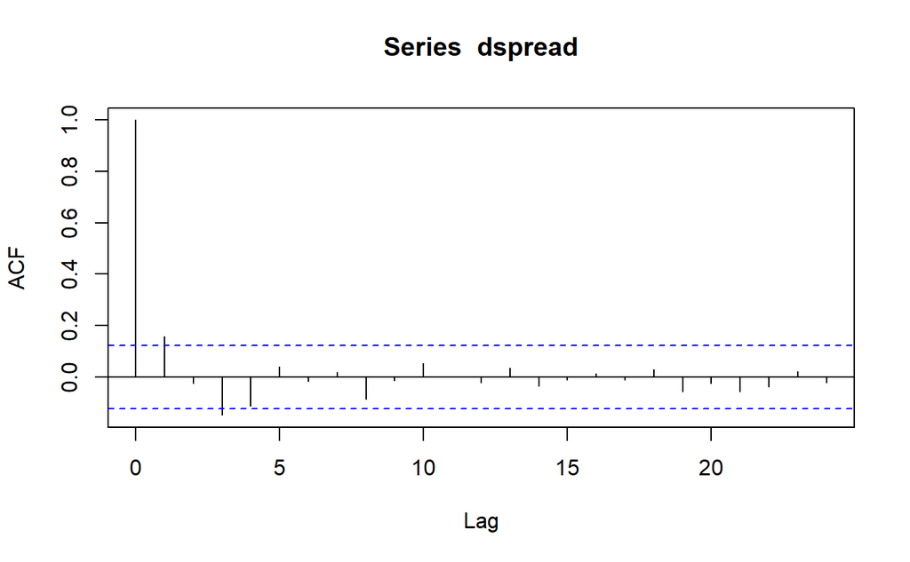

```r
acf(dspread)
```

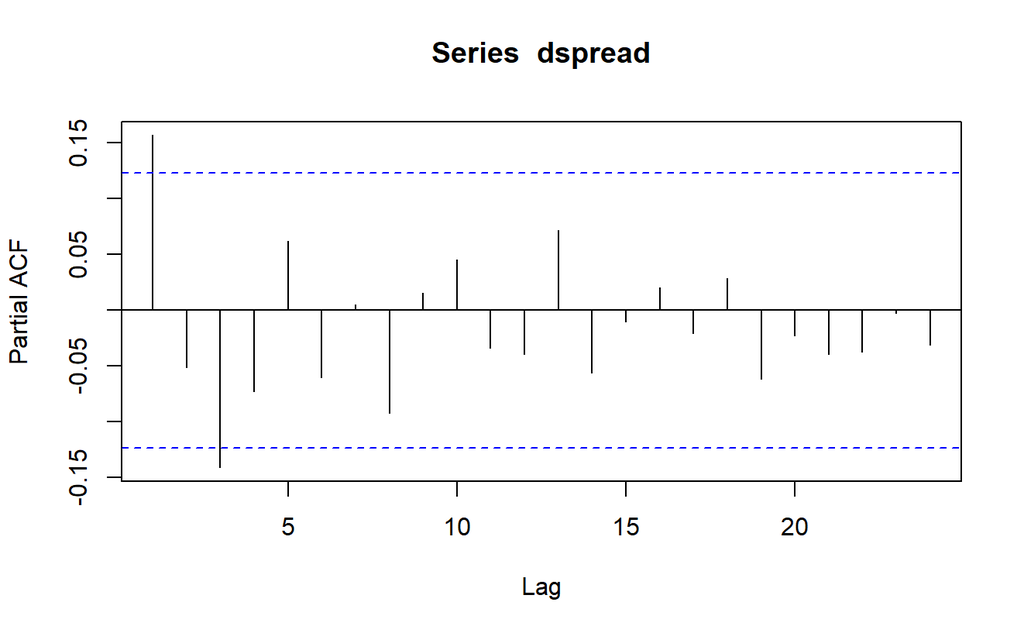

```r
pacf(dspread)
```

L’ACF et la PACF sont significatifs à l’ordre 3 au maximum. On choisit donc : $q^*=3$ et $p^*=3$.

### Question 5 - Critères d’information

```r
library(tidyr)

p_max = 3
q_max = 3

# Le but est de construire pour chaque critère d'information, une matrice dont l'élement (p,q) (indexation commence à 0) correspond au AIC ou BIC du modèle ARMA(p,q) de dpsread

res_AIC = matrix(NA, nrow = (p_max + 1), ncol = (q_max +1))
rownames(res_AIC) <- paste0("p=",0:p_max)
colnames(res_AIC) <- paste0("q=",0:q_max)

res_BIC = res_AIC

# Double boucle pas trop couteuse pour remplir les deux matrices
for(p in 0:(p_max)){
  for(q in (0:q_max)){
    model = arima(x = df_diff$dspread,order = c(p,0,q),include.mean = F)
    res_AIC[p+1,q+1] = AIC(model)
    res_BIC[p+1,q+1] = BIC(model)
  }
}
print("Résultats des AIC : ")
```

```
[1] "Résultats des AIC : "
```

```r
res_AIC == min(res_AIC)
```

```
      q=0   q=1   q=2   q=3
p=0 FALSE FALSE FALSE FALSE
p=1 FALSE FALSE FALSE FALSE
p=2 FALSE FALSE FALSE FALSE
p=3  TRUE FALSE FALSE FALSE
```

```r
print("Résultats des BIC : ")
```

```
[1] "Résultats des BIC : "
```

```r
res_BIC == min(res_BIC)
```

```
      q=0   q=1   q=2   q=3
p=0 FALSE  TRUE FALSE FALSE
p=1 FALSE FALSE FALSE FALSE
p=2 FALSE FALSE FALSE FALSE
p=3 FALSE FALSE FALSE FALSE
```

AIC donne pour dspread : ARMA(3,0), cad AR(3)

BIC donne pour dspread : ARMA(0,1), cad MA(1)

On garde donc ces deux modèles.

### Question 6 : détermination des estimations des paramètres

```r
arima310 = arima(x = df_diff$dspread, order = c(3,0,0),include.mean = F)
arima011 = arima(x = df_diff$dspread, order = c(0,0,1),include.mean = F)

print("Statistique de Student associée au coefficient AR3 du ARIMA(3,1,0): ")
```

```
[1] "Statistique de Student associée au coefficient AR3 du ARIMA(3,1,0): "
```

```r
n_coef = 3
print(abs(arima310$coef[n_coef])/arima310[["var.coef"]][n_coef,n_coef]**(1/2))
```

```
    ar3
2.31102
```

```r
print("Statistique de Student associée au coefficient MA1 du ARIMA(0,1,1): ")
```

```
[1] "Statistique de Student associée au coefficient MA1 du ARIMA(0,1,1): "
```

```r
n_coef = 1
print(abs(arima011$coef[n_coef])/arima310[["var.coef"]][n_coef,n_coef]**(1/2))
```

```
     ma1
2.581247
```

### Question 7 : Test d’auto-corrélation des résidus

```r
Qtests(arima310$residuals, 24, fitdf = 3)
```

```
      lag      pval
 [1,]   1        NA
 [2,]   2        NA
 [3,]   3        NA
 [4,]   4 0.1904740
 [5,]   5 0.3244704
 [6,]   6 0.3887394
 [7,]   7 0.5198373
 [8,]   8 0.3677755
 [9,]   9 0.4841634
[10,]  10 0.4582618
[11,]  11 0.5518845
[12,]  12 0.6177153
[13,]  13 0.6189726
[14,]  14 0.6580996
[15,]  15 0.7349226
[16,]  16 0.7967384
[17,]  17 0.8349330
[18,]  18 0.8636279
[19,]  19 0.8382901
[20,]  20 0.8798865
[21,]  21 0.8816954
[22,]  22 0.8964996
[23,]  23 0.9228724
[24,]  24 0.9203136
```

```r
Qtests(arima011$residuals, 24, fitdf = 1)
```

```
      lag       pval
 [1,]   1         NA
 [2,]   2 0.92643331
 [3,]   3 0.10523875
 [4,]   4 0.06379056
 [5,]   5 0.08516476
 [6,]   6 0.13304951
 [7,]   7 0.18441158
 [8,]   8 0.13648907
 [9,]   9 0.19805273
[10,]  10 0.22104757
[11,]  11 0.29401436
[12,]  12 0.35752605
[13,]  13 0.39639309
[14,]  14 0.44280423
[15,]  15 0.52033893
[16,]  16 0.58985379
[17,]  17 0.65121426
[18,]  18 0.68155921
[19,]  19 0.67066915
[20,]  20 0.72979550
[21,]  21 0.74026930
[22,]  22 0.77131600
[23,]  23 0.80318367
[24,]  24 0.82614283
```

On ne rejette pas au seuil de 5% l’absence d’auto-corrélation des résidus dans les deux cas.

Les deux modèles sont donc **valides**.

### Question 8

Les deux modèles sont tous les deux bien ajustés et valides, et minimisent tous les deux un critère d’information.

On conserve dans les deux modèles à ce stade.

### Question 9 : discussion sur un outlier

Faisons les prédictions avec le modèle ARIMA(3,1,0), car on ne rejette pas à 10% l’absence d’auto-corrélation des résidus, alors qu’on le rejette pour l’autre modèle.

*La correction propose d’utiliser le $R^2$ ajusté pour choisir le modèle utilisé. Le modèle ARIMA(3,1,0) est aussi conservé.*

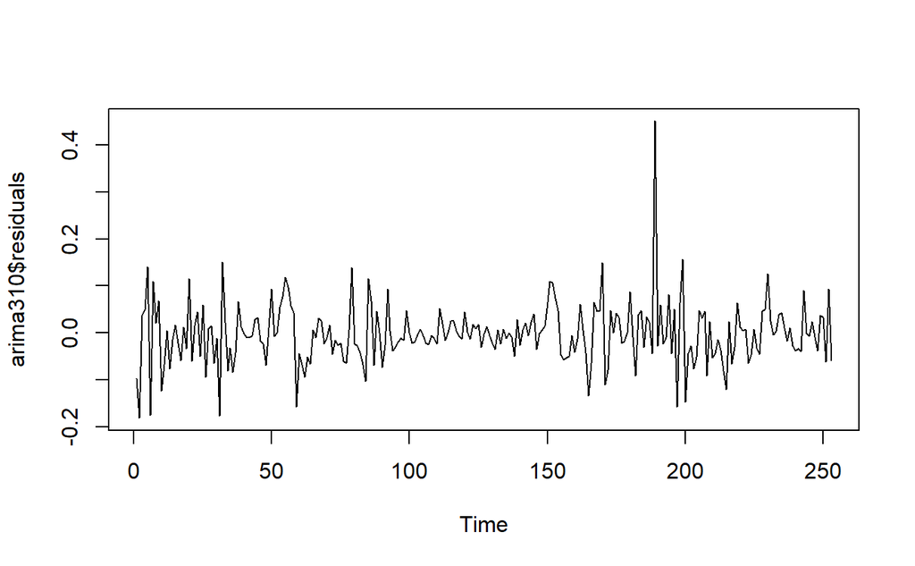

```r
plot(arima310$residuals)
```

On aurait pu prendre en compte cette observation en incluant une indicatrice de cette date dans la regression.

### Question 10 : test de stabilité

On veut vérifier qu’on a un unique modèle sur toute la série.

La représentation de la série non différenciée semblait indiquer une décroissance jusqu’à l’indice 100 environ, et une croissance ensuite.

*Correction* : On peut donc régresser séparément les deux échantillons et voir si on obtient les mêmes modèles ARIMA (voir même les mêmes coefficients, avec un test d’égalité des coefficients).